# sedramina: traffic-data

Mina Sedra

April 6, 2016

Installing and adding the Libraies we will use

```r
library("dplyr")
```

```r
library(ggplot2)
library(plyr)
library('tm')
library('wordcloud')
library(corrgram)
```

Loading the data

```r
data <- read.csv(file = '../traffic-data.csv')
```

Cleaning Data:

first removing the constant columns and the NAs

```r
same <- sapply(data, function(.col){all(.col[1L] == .col)})
same <-as.vector(same)
same[is.na(same)] <- FALSE
dataset <- data[!same]
```

Storing the classes of the columns

```r
classes.of.all.columns <- sapply(data, class)
```

Then removing the duplicates

```r
duplicated_rows = duplicated(dataset$rd.rp.cmid);
dataset <- dataset[!duplicated_rows,]
```

Now the Size of the data is

```r
dim(dataset)
```

```
## [1] 148367     19
```

Since stid has a meanig stid meaning 6 question 7 radar 8 accident 9 3otl 10 attention

Then replacing the NAs in it is according to the comments

```r
question <- is.na(dataset$rd.rp.stid) & (grepl("[?]", dataset$rd.rp.cm, ignore.case=TRUE)|grepl("[؟]", dataset$rd.rp.cm, ignore.case=TRUE))
dataset$rd.rp.stid[question] <- 6


radar <-is.na(dataset$rd.rp.stid) & (grepl("رادار", dataset$rd.rp.cm, ignore.case=TRUE)|grepl("radar", dataset$rd.rp.cm, ignore.case=TRUE))
dataset$rd.rp.stid[radar] <- 7


accident <- is.na(dataset$rd.rp.stid) & (grepl("حادثة", dataset$rd.rp.cm, ignore.case=TRUE)|grepl("حادثه", dataset$rd.rp.cm, ignore.case=TRUE)|grepl("7adsa", dataset$rd.rp.cm, ignore.case=TRUE))
dataset$rd.rp.stid[accident] <- 8


Aotl <- is.na(dataset$rd.rp.stid) & (grepl("3otl", dataset$rd.rp.cm, ignore.case=TRUE)|grepl("عطلانة", dataset$rd.rp.cm, ignore.case=TRUE))
dataset$rd.rp.stid[Aotl] <- 9

#Adding a vector to say is this report is from bey2ollak

from.GPS.Reporter <-dataset$rd.rp.fullnm == "GPS Reporter"
from.GPS.Reporter[is.na(from.GPS.Reporter)] <- FALSE
```

Add the boolean vectors to the data

```r
dataset["question"] <- question
dataset["radar"] <- radar
dataset["accident"] <- accident
dataset["Aotl"] <- Aotl
dataset["Report"] <- from.GPS.Reporter

head(dataset)
```

```
##                     crawl_date                                      rd.nm
## 1 Fri Feb  5 17:23:57 UTC 2016 Makram 3ebeid;Autostrad To Mostafa ElNa7as
## 2 Fri Feb  5 17:23:57 UTC 2016 Makram 3ebeid;Autostrad To Mostafa ElNa7as
## 3 Fri Feb  5 17:23:57 UTC 2016 Makram 3ebeid;Autostrad To Mostafa ElNa7as
## 4 Fri Feb  5 17:23:57 UTC 2016 Makram 3ebeid;Autostrad To Mostafa ElNa7as
## 5 Sat Feb  6 08:01:00 UTC 2016 Makram 3ebeid;Autostrad To Mostafa ElNa7as
## 6 Sat Feb  6 08:01:00 UTC 2016 Makram 3ebeid;Autostrad To Mostafa ElNa7as
##   rd.ri rd.stid rd.hr rd.mn rd.new rd.img rd.strq rd.cmrq        rd.rp.nm
## 1   678       3     1    12      1     NA       1       0     Tahany_Eyad
## 2   678       3     1    12      1     NA       1       0     7abeba_Sa3d
## 3   678       3     1    12      1     NA       1       0     fa3el kheir
## 4   678       3     1    12      1     NA       1       0 ShahinazSale791
## 5   678      NA     9     5      1     NA       1       0    Gad.Badr1998
## 6   678      NA     9     5      1     NA       1       0      Farghaly13
##     rd.rp.fullnm rd.rp.hr rd.rp.mn rd.rp.stid rd.rp.cm rd.rp.cmid
## 1    Tahany Eyad       18       38          2   lazeez    9300046
## 2    7abeba Sa3d       20       26          2   lazeez    9299640
## 3           <NA>       22        6          2   lazeez    9299068
## 4 Shahinaz Sale7       23       47          2   lazeez    9298351
## 5       Gad Badr       23       32          2   lazeez    9300548
## 6     Farghaly13       28       56          1   7alawa    9300224
##   rd.rp.rpImg rd.rp.img question radar accident  Aotl Report
## 1          NA        NA    FALSE FALSE    FALSE FALSE  FALSE
## 2          NA        NA    FALSE FALSE    FALSE FALSE  FALSE
## 3          NA        NA    FALSE FALSE    FALSE FALSE  FALSE
## 4          NA        NA    FALSE FALSE    FALSE FALSE  FALSE
## 5          NA        NA    FALSE FALSE    FALSE FALSE  FALSE
## 6          NA       842    FALSE FALSE    FALSE FALSE  FALSE
```

Add the time where the report actually issued

```r
#change the crawl date postixct
dataset$crawl_date <- as.POSIXct(dataset$crawl_date,format = "%a %b  %d %H:%M:%S",tz = "UTC")

#add reported at
reported.at <- dataset$crawl_date -(dataset$rd.rp.hr * 60 * 60) - (dataset$rd.rp.mn * 60);
dataset["reported.at"] <- reported.at;

dataset <- dataset %>% mutate(report.range= format(reported.at, format="%y-%m-%d %H"))
```

And Visualizing the Correlations

[figure not shown]

```r
corrgram(dataset, order=NULL, lower.panel=panel.shade,upper.panel=NULL, text.panel=panel.txt,main="coleration")
```

Divide the road name to 3 cluomns {from , to , through}

```r
splited.str<-t(data.frame(strsplit(as.character(dataset$rd.nm), "[;]")))
dataset<-dataset%>%mutate(through=splited.str[,1],rd.nm=splited.str[,2])

splited.str <- t(data.frame(strsplit(as.character(dataset$rd.nm), "To")))
dataset<-dataset%>%mutate(from=splited.str[,1],to=splited.str[,2])
```

So the dataset now looks like

```r
head(dataset)
```

```
##            crawl_date                        rd.nm rd.ri rd.stid rd.hr
## 1 2016-02-05 17:23:57 Autostrad To Mostafa ElNa7as   678       3     1
## 2 2016-02-05 17:23:57 Autostrad To Mostafa ElNa7as   678       3     1
## 3 2016-02-05 17:23:57 Autostrad To Mostafa ElNa7as   678       3     1
## 4 2016-02-05 17:23:57 Autostrad To Mostafa ElNa7as   678       3     1
## 5 2016-02-06 08:01:00 Autostrad To Mostafa ElNa7as   678      NA     9
## 6 2016-02-06 08:01:00 Autostrad To Mostafa ElNa7as   678      NA     9
##   rd.mn rd.new rd.img rd.strq rd.cmrq        rd.rp.nm   rd.rp.fullnm
## 1    12      1     NA       1       0     Tahany_Eyad    Tahany Eyad
## 2    12      1     NA       1       0     7abeba_Sa3d    7abeba Sa3d
## 3    12      1     NA       1       0     fa3el kheir           <NA>
## 4    12      1     NA       1       0 ShahinazSale791 Shahinaz Sale7
## 5     5      1     NA       1       0    Gad.Badr1998       Gad Badr
## 6     5      1     NA       1       0      Farghaly13     Farghaly13
##   rd.rp.hr rd.rp.mn rd.rp.stid rd.rp.cm rd.rp.cmid rd.rp.rpImg rd.rp.img
```

[output cut: 20 more lines]

As there is no need in our analysis to have (ad.logo,crawl_date,rd.img) we will drop them

```r
drops <- c("rd.img","ad.logo","crawl_date","rd.stid","rd.hr","rd.mn","rd.new","rd.strq","rd.cmrq")
dataset <- dataset[ , !(names(dataset) %in% drops)]
head(dataset)
```

```
##                          rd.nm rd.ri        rd.rp.nm   rd.rp.fullnm
## 1 Autostrad To Mostafa ElNa7as   678     Tahany_Eyad    Tahany Eyad
## 2 Autostrad To Mostafa ElNa7as   678     7abeba_Sa3d    7abeba Sa3d
## 3 Autostrad To Mostafa ElNa7as   678     fa3el kheir           <NA>
## 4 Autostrad To Mostafa ElNa7as   678 ShahinazSale791 Shahinaz Sale7
## 5 Autostrad To Mostafa ElNa7as   678    Gad.Badr1998       Gad Badr
## 6 Autostrad To Mostafa ElNa7as   678      Farghaly13     Farghaly13
##   rd.rp.hr rd.rp.mn rd.rp.stid rd.rp.cm rd.rp.cmid rd.rp.rpImg rd.rp.img
## 1       18       38          2   lazeez    9300046          NA        NA
## 2       20       26          2   lazeez    9299640          NA        NA
## 3       22        6          2   lazeez    9299068          NA        NA
## 4       23       47          2   lazeez    9298351          NA        NA
## 5       23       32          2   lazeez    9300548          NA        NA
## 6       28       56          1   7alawa    9300224          NA       842
##   question radar accident  Aotl Report         reported.at report.range
## 1    FALSE FALSE    FALSE FALSE  FALSE 2016-02-04 22:45:57  16-02-04 22
## 2    FALSE FALSE    FALSE FALSE  FALSE 2016-02-04 20:57:57  16-02-04 20
## 3    FALSE FALSE    FALSE FALSE  FALSE 2016-02-04 19:17:57  16-02-04 19
## 4    FALSE FALSE    FALSE FALSE  FALSE 2016-02-04 17:36:57  16-02-04 17
## 5    FALSE FALSE    FALSE FALSE  FALSE 2016-02-05 08:29:00  16-02-05 08
## 6    FALSE FALSE    FALSE FALSE  FALSE 2016-02-05 03:05:00  16-02-05 03
##         through       from               to
## 1 Makram 3ebeid Autostrad   Mostafa ElNa7as
## 2 Makram 3ebeid Autostrad   Mostafa ElNa7as
## 3 Makram 3ebeid Autostrad   Mostafa ElNa7as
## 4 Makram 3ebeid Autostrad   Mostafa ElNa7as
## 5 Makram 3ebeid Autostrad   Mostafa ElNa7as
## 6 Makram 3ebeid Autostrad   Mostafa ElNa7as
```

Get the speed from the report first make new dataset from the GPS Reporters only Then add the speed

```r
data.from.GPS.Reporters <- dataset[from.GPS.Reporter,]

pattern.e <-".*\\[(\\d+ km/h)\\].*"
pattern.a <-".*\\[(\\d+ كم/س)\\].*"

s.e =  gsub(pattern.e, "\\1",dataset$rd.rp.cm[from.GPS.Reporter])
s.a =  gsub(pattern.a, "\\1",dataset$rd.rp.cm[from.GPS.Reporter])

s.a[nchar(s.a)>10] <- "0"
s.a <- as.numeric(gsub("([0-9]+).*$", "\\1", s.a))
s.a[is.na(s.a)]= 0
s.e[nchar(s.e)>10] <- "0"
s.e <- as.numeric(gsub("([0-9]+).*$", "\\1", s.e))
s.e[is.na(s.e)]= 0

data.from.GPS.Reporters["speed"] <- as.numeric(gsub("([0-9]+).*$", "\\1", s.a)) + as.numeric(gsub("([0-9]+).*$", "\\1", s.e))

head(data.from.GPS.Reporters)
```

```
##                             rd.nm rd.ri     rd.rp.nm rd.rp.fullnm rd.rp.hr
## 17   Autostrad To Mostafa ElNa7as   678 bey2ollakgps GPS Reporter       23
## 18   Autostrad To Mostafa ElNa7as   678 bey2ollakgps GPS Reporter       24
## 219  Autostrad To Mostafa ElNa7as   678 bey2ollakgps GPS Reporter       23
## 359  Autostrad To Mostafa ElNa7as   678 bey2ollakgps GPS Reporter       21
## 1531           Ba7ary To Mansheya   321 bey2ollakgps GPS Reporter       33
## 1585           Ba7ary To Mansheya   321 bey2ollakgps GPS Reporter       23
##      rd.rp.mn rd.rp.stid
## 17         53          3
## 18         13          3
## 219        19          4
## 359        47          2
## 1531       41         10
## 1585       45         10
##                                                                                 rd.rp.cm
```

[output cut: 27 more lines]

To see what the people’s most fequent words used to express that the road is 7alawa so we will use Function to analyze the comments and get the frequency the words in the comments with specific stid

```r
comment_analysis <- function(n){
rdata <- dataset[dataset$rd.rp.stid == n,  ]
rdata <- rdata[!rdata$Report,]
review_text <- paste(rdata$rd.rp.cm, collapse=" ")

review_source <- VectorSource(review_text)
corpus <- Corpus(review_source)

corpus <- tm_map(corpus, content_transformer(tolower))
corpus <- tm_map(corpus, removePunctuation)
corpus <- tm_map(corpus, stripWhitespace)
corpus <- tm_map(corpus, removeWords, stopwords("english"))
corpus <- tm_map(corpus, removeWords, c("إلى","شارع","أخد","الطريق","kmh","كم/س","average","speed","لحد"))

dtm <- DocumentTermMatrix(corpus)
dtm2 <- as.matrix(dtm)

frequency <- colSums(dtm2)
frequency <- sort(frequency, decreasing=TRUE)
words <- names(frequency[1:20])
wordcloud(words[1:20], frequency[1:20])
return (frequency[1:20])
}
```

So for 7alawa

[figure not shown]

```r
comment_analysis(1);
```

And the same for lazeez

[figure not shown]

```r
comment_analysis(2)
```

And for mashy

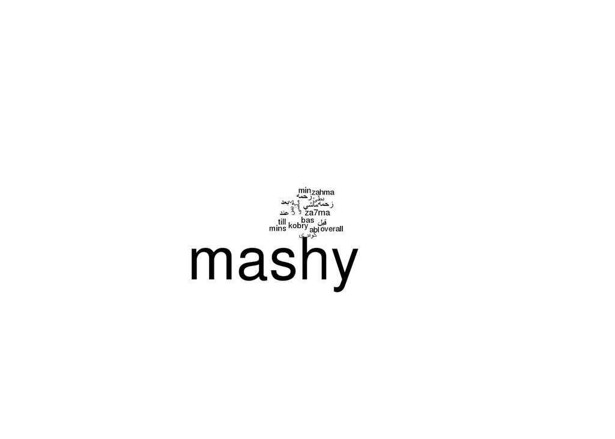

```r
comment_analysis(3)
```

And for za7ma

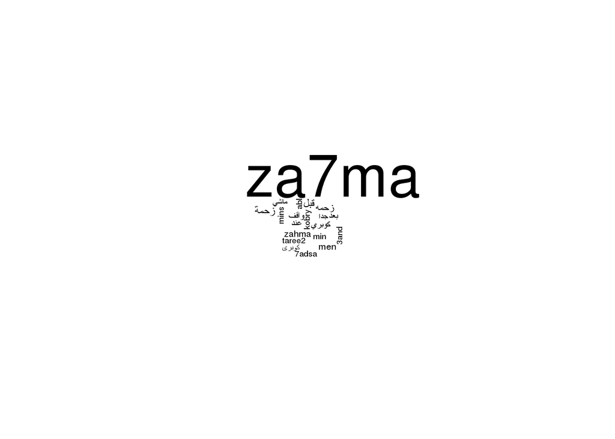

```r
comment_analysis(4)
```

And for mafeesh 2amal

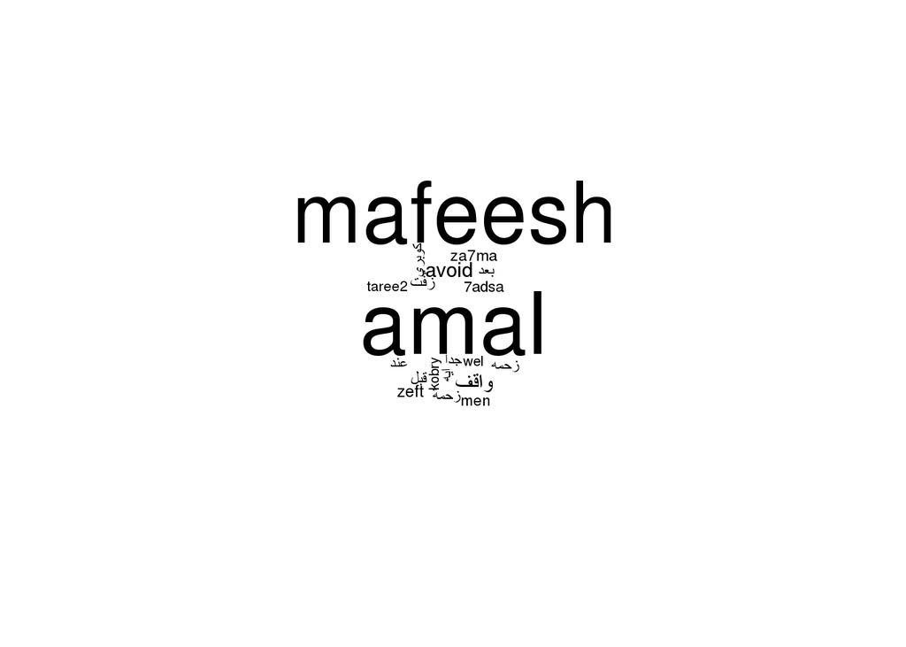

```r
comment_analysis(5)
```

Also for radars

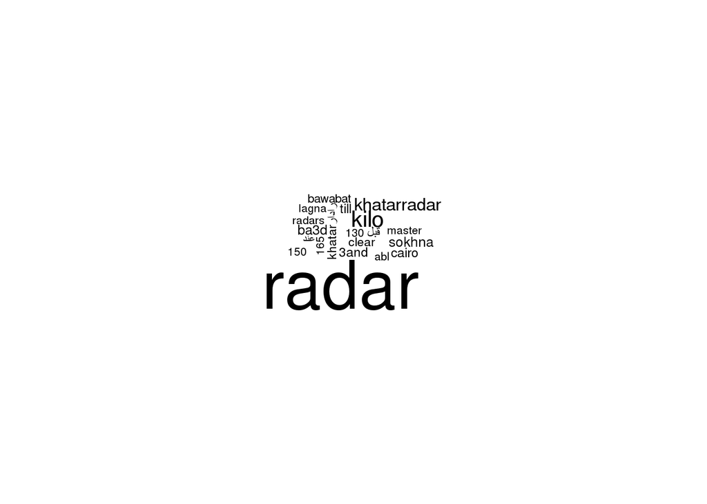

```r
comment_analysis(7)
```

And for 3otl

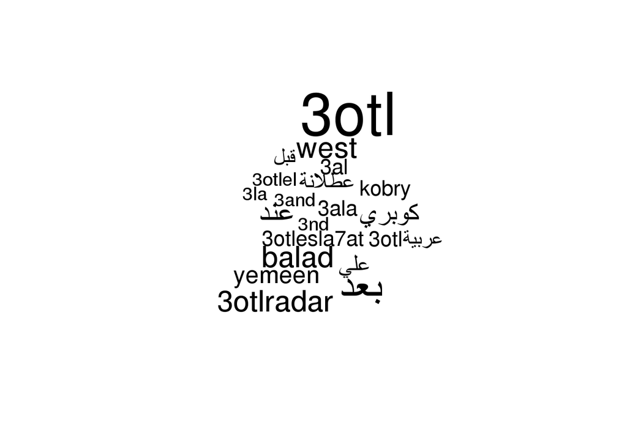

```r
comment_analysis(9)
```

Also we can know the top 5 active users

```r
users.count <- table(dataset$rd.rp.fullnm)
users.count <- sort(users.count, decreasing=TRUE)
users.count[1:5]
```

[output not shown]

And of course GPS Reporter is the most active user so this histogram only for users

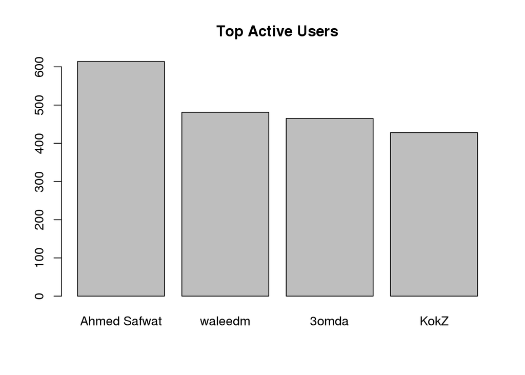

```r
barplot(users.count[2:5], main="Top Active Users")
```

Now analyse by road so for exapmle we will take “Ghamra To Masged ElNour”

So this is will show a graph the speed vs time for this road and it will color the points according to the report type 1 - 7alawa 2 - lazeez 3 - mashy 4 - za7ma 5 - mafeesh 2amal

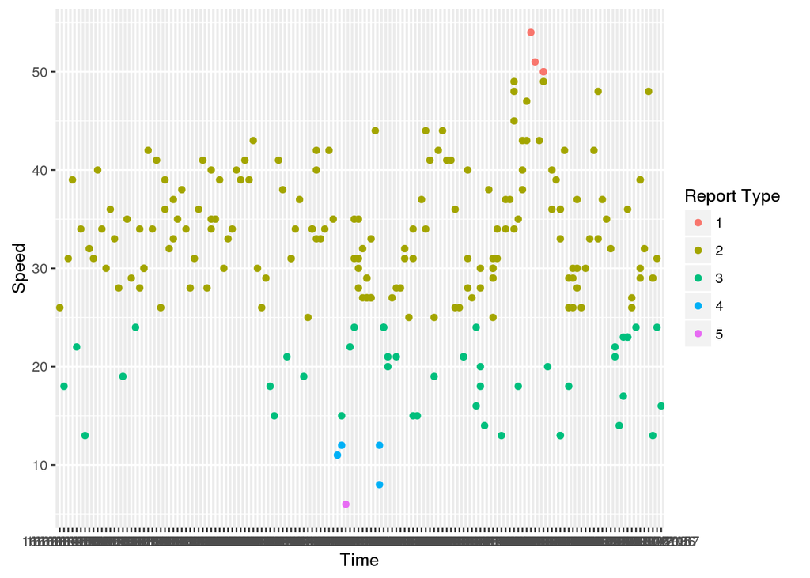

```r
Ghamra_Masged.ElNour = data.from.GPS.Reporters[data.from.GPS.Reporters$rd.nm == "Ghamra To Masged ElNour" ,]
ggplot(aes(x = Ghamra_Masged.ElNour$report.range, y = Ghamra_Masged.ElNour$speed), data = Ghamra_Masged.ElNour ,labels()) +  geom_point(aes(colour = factor(Ghamra_Masged.ElNour$rd.rp.stid))) + labs(x = "Time",y = "Speed",colour = "Report Type")+expand_limits(x=c(0,30))
```

And for all time

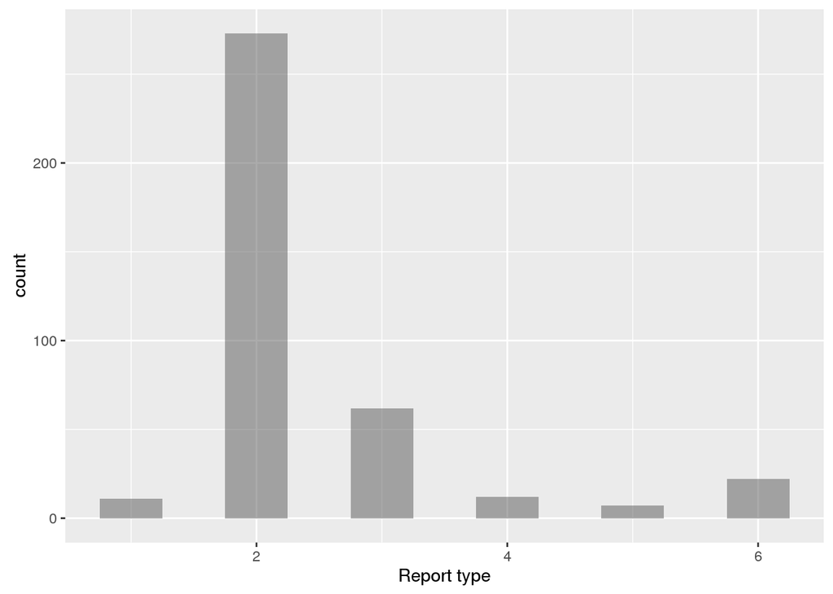

```r
Ghamra_Masged.ElNour = dataset[dataset$rd.nm == "Ghamra To Masged ElNour" ,]

ggplot(Ghamra_Masged.ElNour, aes(x=rd.rp.stid )) +
  geom_histogram(binwidth=.5, alpha=.5, position="identity") + labs(x = "Report type",y = "count",colour = "Report Type")
```